# Instacart Analysis 2017

Michael Garcia

July 6, 2017

##### modified date: July 23, 2017

INS0923920381WD202C

### Data Overview

Instacart Analysis is derived from the R scripts in the insta_public_analysis project. See end of file for license details.

The summary below represents the frequency distribution of the number of orders per user.

```
   Min. 1st Qu.  Median    Mean 3rd Qu.    Max.
   3.00    5.00    9.00   15.59   19.00   99.00
```

### License and Notices

##### Data Source:

The Instacart Online Grocery Shopping Dataset 2017”, Accessed from https://www.instacart.com/datasets/grocery-shopping-2017 on July 2017

###### This project was developed on R System for Statistical Computation and Graphics. All source code is in R Programming Language. For information see https://www.r-project.org/about.html

##### License and Copyright

```
 Project: insta_public_analysis project
 Copyright(C) Michael Garcia 2017. All Rights Reserved.
 GNU General Public License Version 3
 Contact Author: mgar_datascience at protonmail dot com

 This program is distributed in the hope that it will be useful,
 but WITHOUT ANY WARRANTY; without even the implied warranty of
 MERCHANTABILITY or FITNESS FOR A PARTICULAR PURPOSE.  See the
 GNU General Public License Version 3 for more details.
 See http://www.gnu.org/licenses for full license. Additional Licenses
 may apply. Run source(listPckg) for a list of installed packages and
 licenses.
```

#### Users and Day of Week

Sunday was the most popular day to place orders at 151528. Friday was the lease popular day to place orders at 128327.

## Day and Hour Shopping

### Day of Week Shopping

The full distribution is available below as a data table and graph:

| order_dow | no_dist_users |
| --- | --- |
| 0 | 145300 |
| 1 | 151528 |
| 2 | 140248 |
| 3 | 135375 |
| 4 | 132186 |
| 5 | 133893 |
| 6 | 128327 |

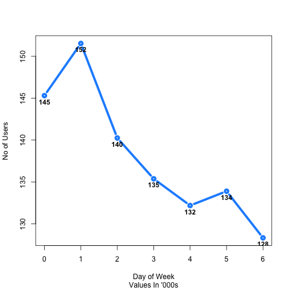

Day of Week

### Hour of Day Shopping

The hour of the day that was most shopped was hour 15 with a log10 total of 5.06 Orders and ranges from 10 -15 around 5 total orders.

The chart belows plots the points of total orders at the respective hours placed

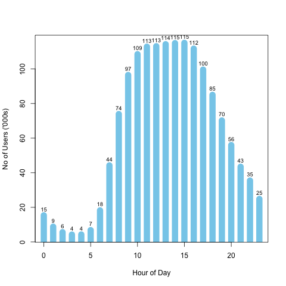

### Day Of Week Ice Cream

This graph represents day of week orders for Ice Cream Aisle. Product Names are different within the aisle.

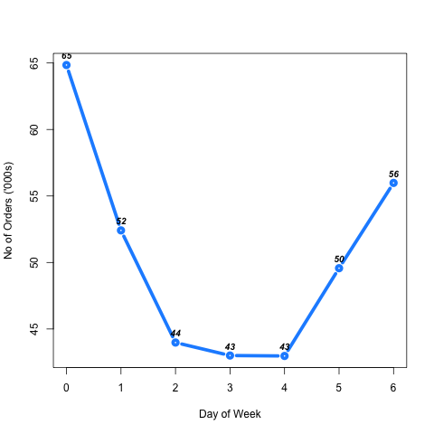

### Hour of Day Ice Cream

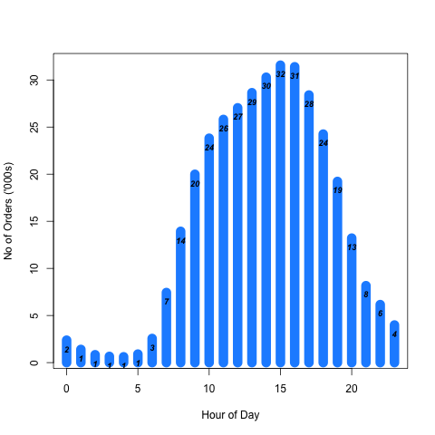

## Re Orders

### Days since prior order- Ice Cream

```
Ignoring unknown parameters: binwidth, bins, pad
```

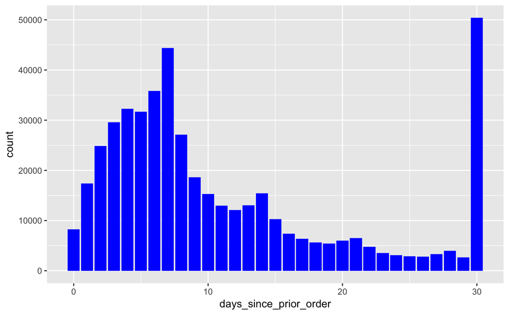

### How Many prior orders - Ice Cream

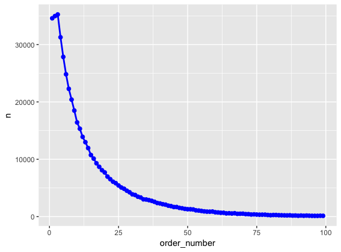

##

## Orders and Basket Size

### Basket Variety - Product Combinations

The graph shows the variety of the basket. The unique products in a basket decreases through the customers lifecyle. Note that there is one order_id outlier that has 145 unqiue product_ids in the order.

Another interesting point; there seems to be a strong positive correlation in the quantity of unique products to the quantity of prior reorders (see How Many prior orders chart above) . So not only does the product basket variety decrease, but so does the number of future orders.

This might show potential symptoms that a customer might “churn out” if the quantity of unique products decreases. We would need to perform a deeper analysis and hypothesis test to rule out other factors such as; seasonality, duration of products, etc.

The outlier can be seen in the following distribution:

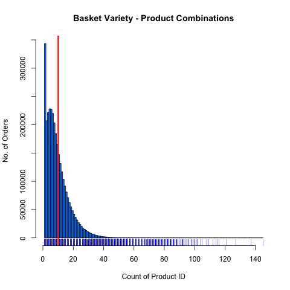

Distribution of ProductID Combinations

```
   Min. 1st Qu.  Median    Mean 3rd Qu.    Max.
   1.00    5.00    8.00   10.09   14.00  145.00
```

|  | department | aisle | orderCount |
| --- | --- | --- | --- |
| 59 | frozen | frozen juice | 4853 |
| 9 | personal care | beauty | 6168 |
| 3 | babies | baby accessories | 8160 |
| 4 | babies | baby bath body care | 8581 |
| 45 | personal care | eye ear care | 8974 |
| 77 | household | kitchen supplies | 9172 |
| 116 | personal care | skin care | 10164 |
| 115 | personal care | shave needs | 10344 |
| 48 | personal care | first aid | 10872 |
| 122 | alcohol | specialty wines champagnes | 11198 |

[output cut: 124 more lines]

### Basket Size - Ice Cream

A basket that includes ice cream is likely to have around 1 or 2 different product id’s:

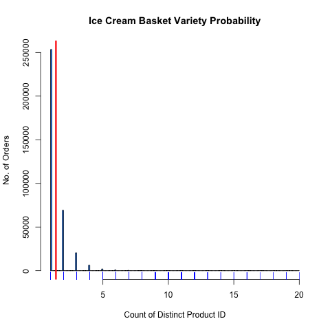

### Reorders and Proportions - Ice Cream Only

Purchase frequency and most often reordered

| reordered | count | proportion |
| --- | --- | --- |
| 0 | 253025 | 0.51 |
| 1 | 245400 | 0.49 |

### Reordered Proportion

| reordered | count | proportion |
| --- | --- | --- |
| 0 | 253025 | 0.5076491 |
| 1 | 245400 | 0.4923509 |

### Top Proportion Reordered

| product_id | proportion_reordered | n | product_name | aisle_id | department_id |
| --- | --- | --- | --- | --- | --- |
| 48763 | 0.8275862 | 87 | Lemon Ice Cubes | 37 | 1 |
| 39210 | 0.7790698 | 86 | Super Premium Chocolate Ice Cream | 37 | 1 |
| 34929 | 0.7634409 | 93 | Chocolate Cookie with Salted Caramel Ice Cream | 37 | 1 |
| 43856 | 0.7457627 | 59 | Ice Cream | 37 | 1 |
| 33151 | 0.7399527 | 423 | Gluten free Dark Chocolate covered Creamy Banana Fruit Bars | 37 | 1 |
| 24538 | 0.7352941 | 68 | Frozen Dessert, Non-Dairy, Mocha Pie | 37 | 1 |
| 42488 | 0.7317073 | 41 | Chocolate Nutty Bar Non Dairy Frozen Dessert | 37 | 1 |
| 13375 | 0.7127883 | 477 | Vitaminwater Zero Focus Kiwi-Strawberry | 37 | 1 |
| 38778 | 0.7125000 | 80 | Non Dairy Frozen Vanilla Pie Dessert | 37 | 1 |
| 45772 | 0.7125000 | 80 | Ice Cream Vanilla | 37 | 1 |

[output cut: 90 more lines]

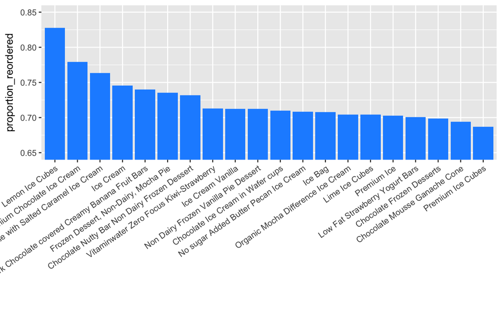

## Basket Size Trend

### Basket Size Trend

The scatterplot shows an increase in product variety in each order from the first to the 30th order. Then the curve of the trend shifts downward after the 30th order.

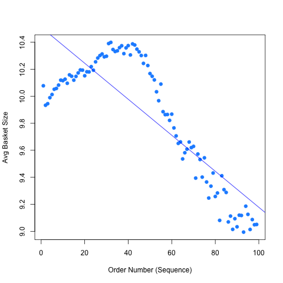

Basket Size Trend

| order_number | avg_basketsize |
| --- | --- |
| 1 | 10.077484 |
| 2 | 9.933281 |
| 3 | 9.944915 |
| 4 | 9.989398 |
| 5 | 10.012796 |
| 6 | 10.051602 |
| 7 | 10.057813 |
| 8 | 10.082436 |
| 9 | 10.119103 |
| 10 | 10.115481 |

[output cut: 89 more lines]

### Basket Size Variance

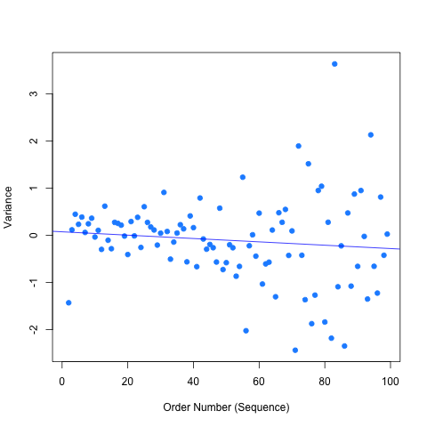

Variance of Data

### Ice Cream Basket Trend

This graph suggests that when compared to the total average basket trend, the average of ice cream is a part of the basket anywhere between the first and 90th order and will have 1.6 to 2.0 types of ice cream. It does decrease , but since you cannot have partial ice cream product, it is most likely 2 different product ids.

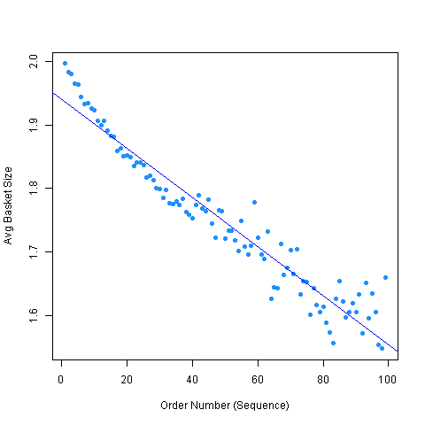

Ice Cream Basket Trend

### Ice Cream basket Variance

This graph suggests 2 different types of ice cream products within first 20 orders; variance will increase by up to 6 percent, but still not significant from the fitted line.

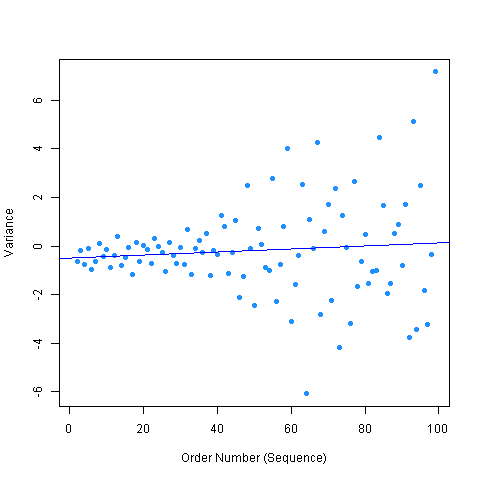

##

## Top Selling Products

The table below shows the top product names.

### All Dept & Aisle

This treemap covers all departments and aisles.

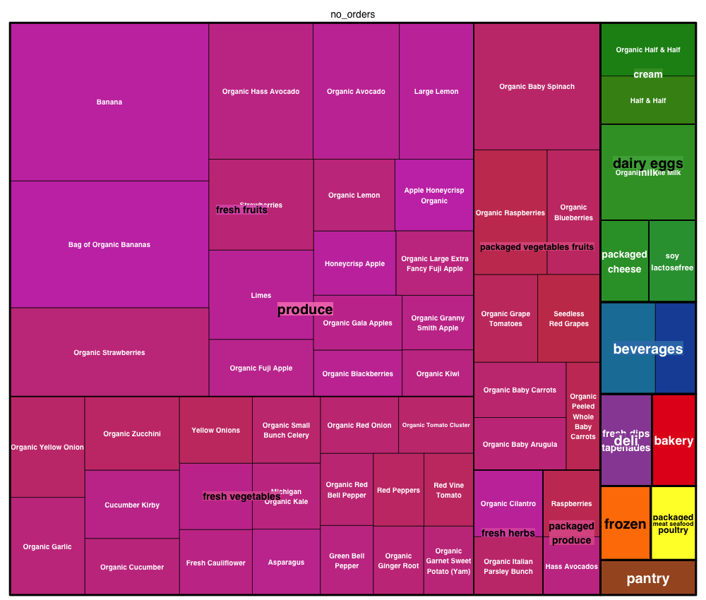

This table shows top products:

|  | department | aisle | product_name | no_orders |
| --- | --- | --- | --- | --- |
| 3666 | produce | fresh fruits | Banana | 472565 |
| 3459 | produce | fresh fruits | Bag of Organic Bananas | 379450 |
| 31949 | produce | fresh fruits | Organic Strawberries | 264683 |
| 28867 | produce | packaged vegetables fruits | Organic Baby Spinach | 241921 |
| 30326 | produce | fresh fruits | Organic Hass Avocado | 213584 |
| 28832 | produce | fresh fruits | Organic Avocado | 176815 |
| 22440 | produce | fresh fruits | Large Lemon | 152657 |
| 42937 | produce | fresh fruits | Strawberries | 142951 |
| 23448 | produce | fresh fruits | Limes | 140627 |
| 32507 | dairy eggs | milk | Organic Whole Milk | 137905 |

[output cut: 30 more lines]

### Frozen & Ice Cream

Barplot of the top selling Ice Cream Products.

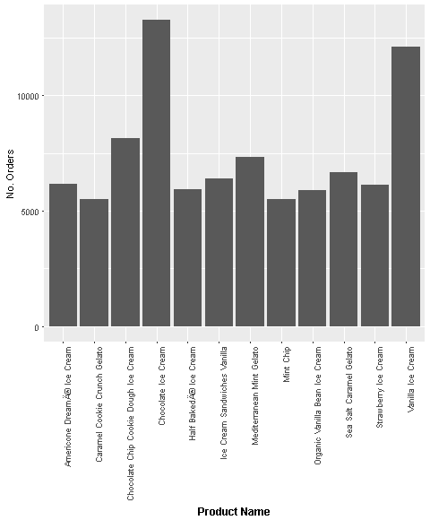

Frozen department and Ice Cream Aisle

Table showing the to Ice Cream Products:

|  | department | aisle | product_name | no_orders |
| --- | --- | --- | --- | --- |
| 8534 | frozen | ice cream ice | Chocolate Ice Cream | 13273 |
| 47107 | frozen | ice cream ice | Vanilla Ice Cream | 12117 |
| 8349 | frozen | ice cream ice | Chocolate Chip Cookie Dough Ice Cream | 8137 |
| 24864 | frozen | ice cream ice | Mediterranean Mint Gelato | 7319 |
| 39529 | frozen | ice cream ice | Sea Salt Caramel Gelato | 6671 |
| 20770 | frozen | ice cream ice | Ice Cream Sandwiches Vanilla | 6394 |
| 2319 | frozen | ice cream ice | Americone Dream® Ice Cream | 6155 |
| 43060 | frozen | ice cream ice | Strawberry Ice Cream | 6129 |
| 19085 | frozen | ice cream ice | Half Baked® Ice Cream | 5928 |
| 32303 | frozen | ice cream ice | Organic Vanilla Bean Ice Cream | 5892 |

[output cut: 5 more lines]